# Homework 1

```r
library(tidyverse)
library(lubridate)
```

## Warm up

Given the vector below:

```r
quiz_scores <- c(78, 85, 92, 67, 88, 95, 73, 84)
```

Write R code to:

1. Print the first score.
2. Print the last score.
3. Calculate the average score.
4. Create a new vector containing only scores greater than or equal to 80.
5. Count how many students scored below 80.

```r
print(paste("1.", quiz_scores[1]))
```

```
## [1] "1. 78"
```

```r
print(paste("2.", quiz_scores[length(quiz_scores)]))
```

```
## [1] "2. 84"
```

```r
print(paste("3.", mean(quiz_scores)))
```

```
## [1] "3. 82.75"
```

```r
below_80 <- quiz_scores[quiz_scores < 80]
below_80 <- paste(below_80)
print(paste("4. below 80:",paste(below_80, collapse = " ")))
```

```
## [1] "4. below 80: 78 67 73"
```

```r
print(paste("5.", length(below_80)))
```

```
## [1] "5. 3"
```

Write a function called `letter_grade()` that takes a numeric score and returns:

| Score Range | Grade |
| --- | --- |
| 90 or above | A |
| 80–89 | B |
| 70–79 | C |
| 60–69 | D |
| Below 60 | F |

Example:

```r
letter_grade(92)
```

Expected output:

```r
[1] "A"
```

```r
letter_grade<-function(score){
if(score >= 90){
    return("A")
  }
  if(score >= 80 & score <90){
    return("B")
  }
   if(score >= 70 & score <80){
    return("C")
  }
  if(score >= 60 & score <70){
    return("D")
  }
   if(score < 60){
    return("F")
  }
}
```

Then:

7. Create a data frame using the `quiz_scores` vector.
8. Create a new column named `Letter_Grade` by applying the `letter_grade()` function.

```r
quiz_scores_df <- as.data.frame(quiz_scores)
Letter_Grade <- sapply(quiz_scores, letter_grade)
quiz_scores_df <- cbind(quiz_scores_df, Letter_Grade)
```

Add the following vector as a column named `HoursOfStudy`:

```r
study_hours <- c("1", "1.5", "2.5", "0", "1", "1.5", "0.5", "1")
quiz_scores_df <- cbind(quiz_scores_df, study_hours )
colnames(quiz_scores_df)[3] <- "HoursOfStudy"
```

Once you create the column, do the following:

9. Change the column to numeric.
10. Create a plot using `HoursOfStudy` and `quiz_scores`.
11. Make the plot look polished and readable.

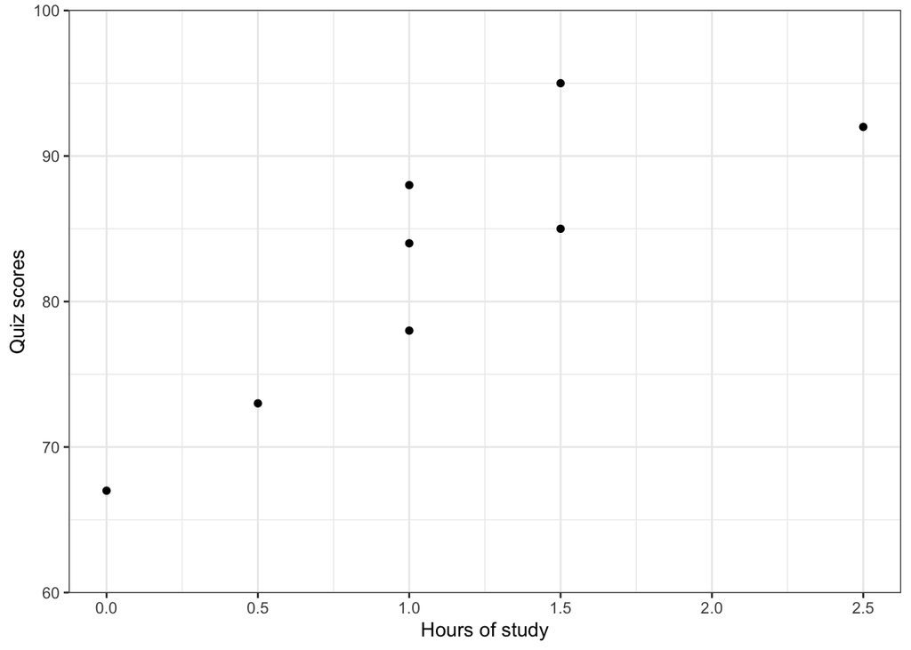

```r
quiz_scores_df$HoursOfStudy <- as.numeric(quiz_scores_df$HoursOfStudy)

ggplot()+
  geom_point(data=quiz_scores_df, aes(x=HoursOfStudy, y=quiz_scores))+
  #ylim(c(60,100), )+
  scale_y_continuous(limits=c(60,100), expand=c(0.001))+
  ylab("Quiz scores")+
  xlab("Hours of study")+
  theme_bw()
```